# NP AMR analyses

# Per-sample ML probability histograms

## Moraxella catarrhalis

Per-sample histograms were generated to visualise ML probability distributions across *Moraxella catarrhalis* isolates.

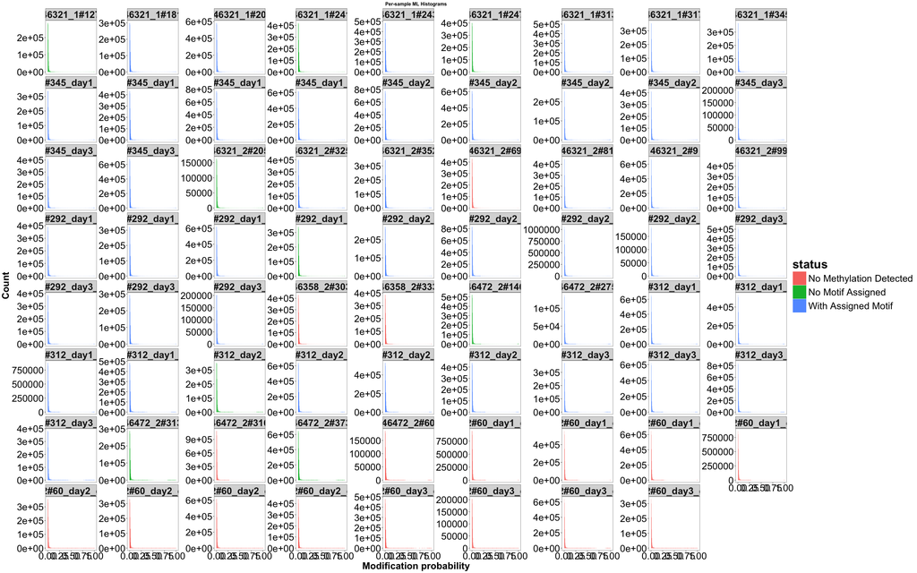

## Haemophilus influenzae

Per-sample histograms were generated to visualise ML probability distributions across *Haemophilus influenzae* isolates.

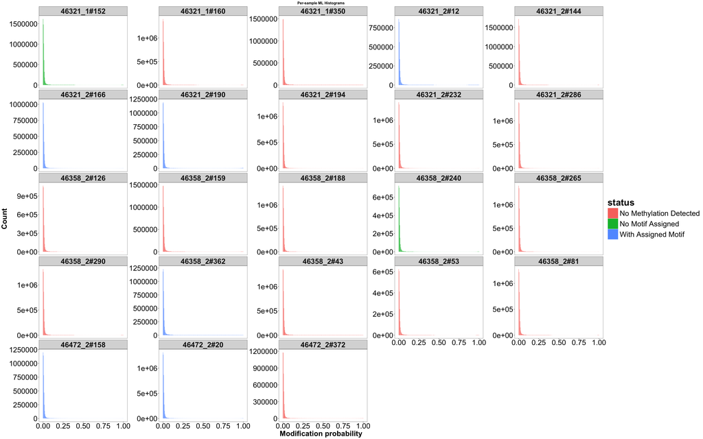

# Restriction–modification system analysis

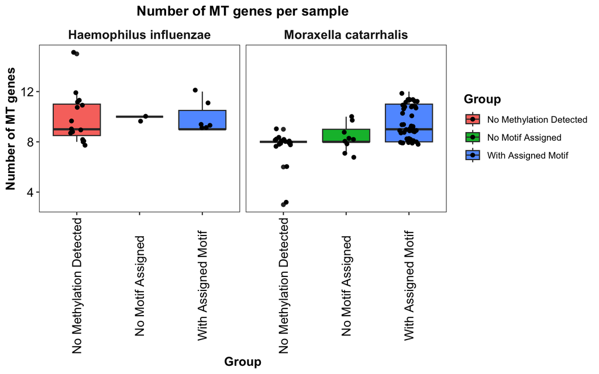

# Methyltransferase heatmaps

## Moraxella catarrhalis methyltransferase heatmap

The distribution of methyltransferase homologs across *Moraxella catarrhalis* isolates was visualised using clustered heatmaps based on alignment lengths.

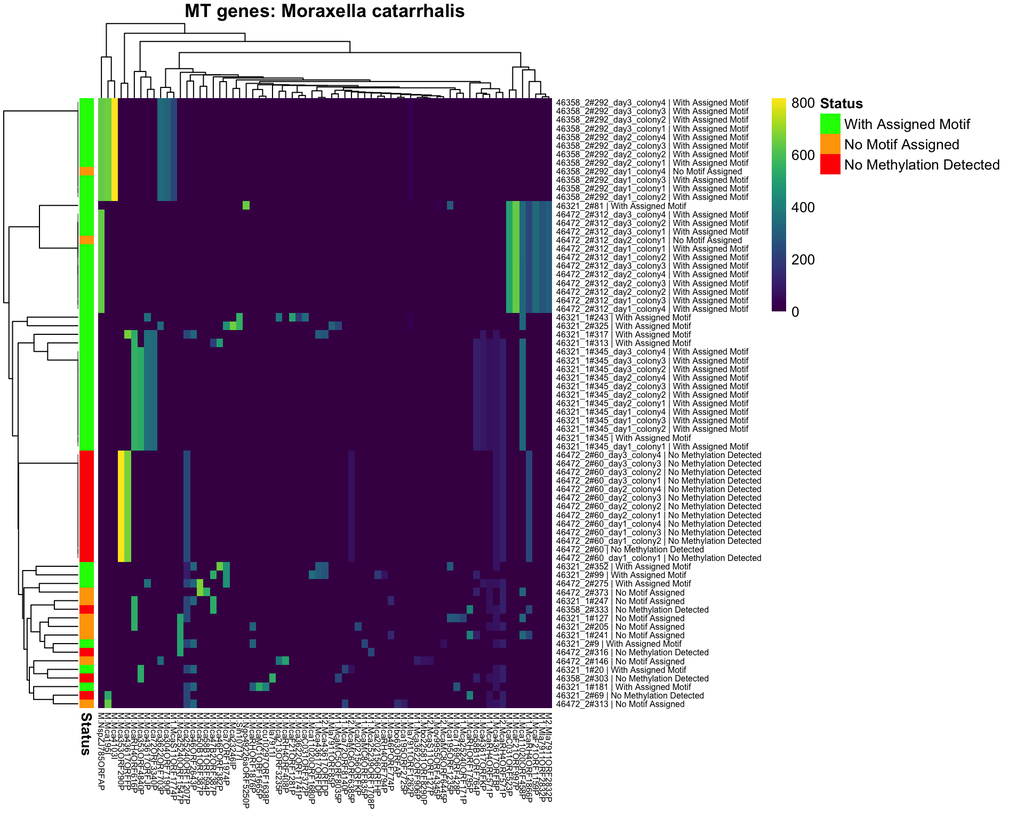

## Haemophilus influenzae methyltransferase heatmap

The distribution of methyltransferase homologs across *Haemophilus influenzae* isolates was visualised using clustered heatmaps based on alignment lengths.

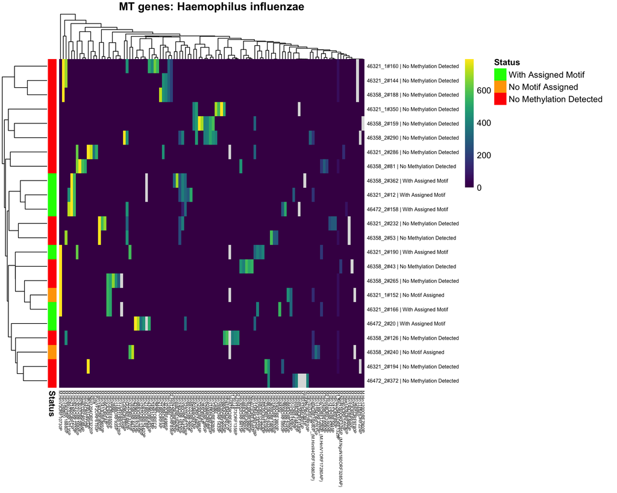

Restriction–modification system annotations generated by MicrobeMod were used to characterise methyltransferase families across isolates.

# Motif summary table

## Create motif families

Motifs were grouped into broader motif families to simplify interpretation and facilitate comparison between *Moraxella catarrhalis* and *Haemophilus influenzae* methylation profiles.

# Summarise motifs per species

Summary statistics were calculated for each motif, including prevalence, methylation levels, and coverage across samples.

# Collapse singleton motifs

Rare motifs identified in single isolates were collapsed into a single “Singleton motifs” category to improve table readability.

# Generate publication-ready table

Summary of methylated motifs by species

| Motif family | Motif | N samples | Mean methylation (%) | Mean coverage | Mean genome sites | Mean methylated sites | Prevalence |
| --- | --- | --- | --- | --- | --- | --- | --- |
| Haemophilus influenzae |  |  |  |  |  |  |  |
| GCGC-like | RGCGCY | 3 | 0.8 | 0.9 | 476.0 | 440.7 | 37.5% |
| Rare motifs | Singleton motifs | 3 | 0.8 | 0.7 | 379.3 | 244.3 | 12.5% |
| GCGC-like | Singleton motifs | 2 | 0.8 | 0.4 | 3416.0 | 2320.5 | 12.5% |
| No motif assigned | No Motif Assigned | 2 | 0.8 | NaN | NaN | 650.0 | 25% |
| Moraxella catarrhalis |  |  |  |  |  |  |  |
| GCGC-like | GCGC | 23 | 0.8 | 0.7 | 2831.1 | 1993.0 | 42.6% |
| Rare motifs | Singleton motifs | 21 | 0.8 | 0.7 | 3448.8 | 653.8 | 1.9% |
| GCGC-like | Singleton motifs | 14 | 0.8 | 0.9 | 443.1 | 344.1 | 1.9% |
| GCGC-like | RGCGCY | 10 | 0.8 | 0.9 | 763.8 | 723.0 | 18.5% |
| No motif assigned | No Motif Assigned | 9 | 0.8 | NaN | NaN | 1330.1 | 16.7% |
| Rare motifs | CCGG | 7 | 0.8 | 0.9 | 375.4 | 344.0 | 13% |
| GCGC-like | GCGCY | 3 | 0.8 | 0.8 | 1582.7 | 1279.7 | 5.6% |
| Rare motifs | AGGCAAAAGC | 3 | 0.9 | 0.3 | 15.0 | 4.0 | 5.6% |
| Rare motifs | ANCACCGG | 2 | 0.9 | 1.0 | 26.5 | 26.5 | 3.7% |
| Rare motifs | CGSCG | 2 | 0.8 | 0.9 | 3628.0 | 3356.0 | 3.7% |

The final table summarises methylation motif distributions and prevalence across both bacterial species.

# Restriction–modification methyltransferase family distribution

## Summarise methyltransferase family frequencies

```
##               RM_family                Species Frequency
## 1   Type_I_MTases_FAM_0 Haemophilus influenzae        41
## 2   Type_I_MTases_FAM_3 Haemophilus influenzae        20
## 3  Type_II_MTases_FAM_0 Haemophilus influenzae        23
## 4  Type_II_MTases_FAM_1 Haemophilus influenzae         3
## 5 Type_II_MTases_FAM_11 Haemophilus influenzae         5
## 6 Type_II_MTases_FAM_13 Haemophilus influenzae         4
```

Restriction–modification methyltransferase families were quantified across *Moraxella catarrhalis* and *Haemophilus influenzae* isolates to compare species-specific R–M system composition.

# Bubble plot of R–M families

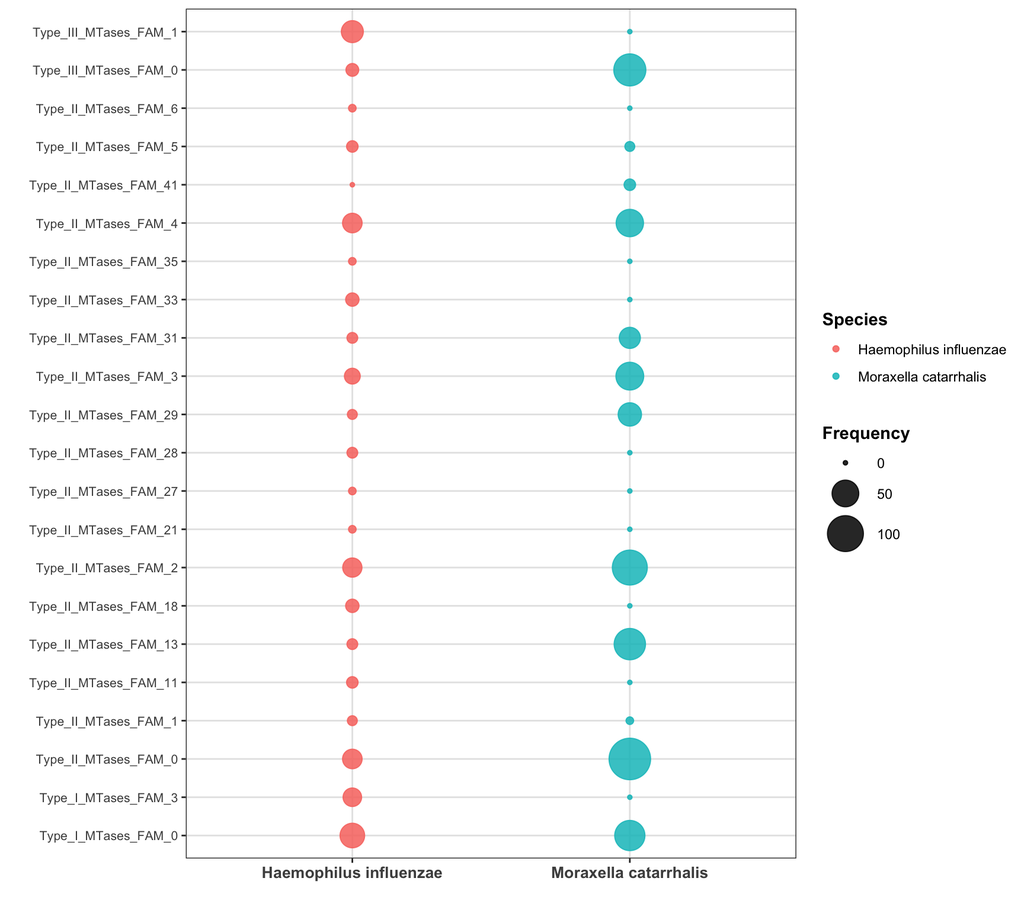

The bubble plot highlights species-specific differences in the abundance and distribution of restriction–modification methyltransferase families between *Moraxella catarrhalis* and *Haemophilus influenzae*.

# Analysis of deep sequencing data

## Co-colonisation analysis of species

- Which species co-exist, and which compete, based on the observed deep sequencing data?

To answer this question, I used the Kraken/Bracken output to perform the following steps:  
1. Generated an abundance table at the species level.  
2. Filtered out all single-infection samples.  
3. Performed a Pearson correlation test across species to obtain a correlation matrix.  
4. Visualised the results using ggplot2.

#### Visualisation of pearson correlation: Species co_colonisation in mixed infection from deep sequencing data in Cambodia and Thailand

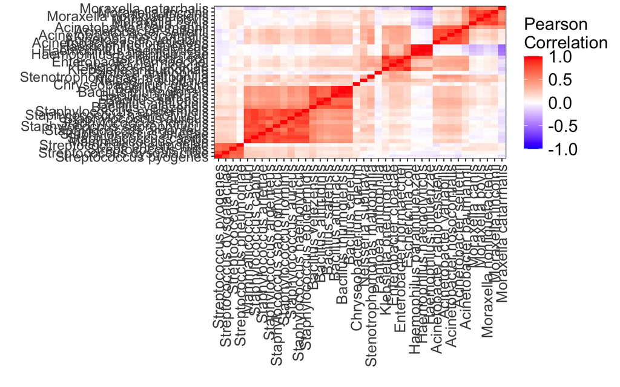

#### Visualisation of pearson correlation:Species co_colonisation in mixed infection per Country

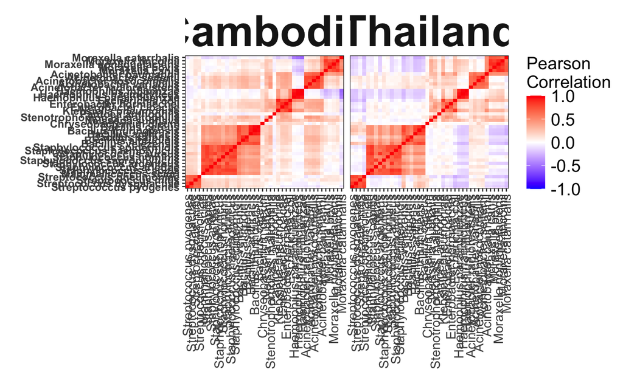

This analysis revealed a **competition** between *Haemophilus influenzae*, and *Moraxella catarrhalis*.

To confirm this observation, we clustered samples/species using bluster/TreeSummarizedExperiment/mia packages.

To do this:

1. I first created a tse object using TreeSummarizedExperiment.
2. I Filtered out species with low proportion to ease the calculation.
3. I added clusters with addcluster and HclustParam functions.
4. I generated a table with the number of samples contributing for each cluster.
5. I got the hclust data from metadata.
6. I used as.dendrogram and color_branches functions from dendextend package to convert hclust data and color the graph.

#### Add sample cluster

```
##
##   1   2   3   4   5   6
## 319 518 281 261 127  72
```

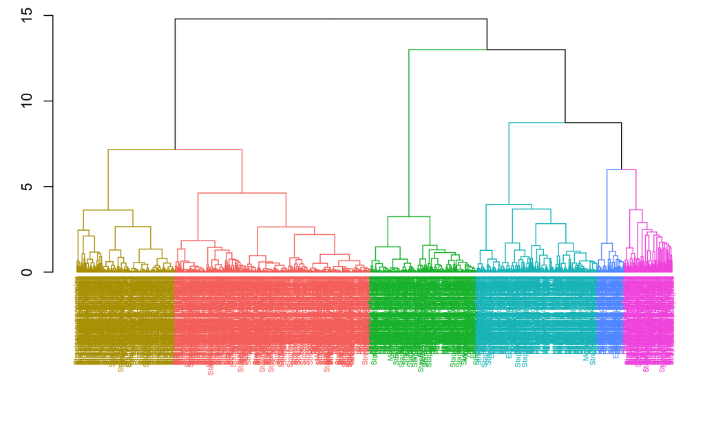

#### Dominant species per clester.

Dominant species were extracted from individual samples across clusters to identify species contributions to each cluster.

A summary table was generated to quantify the frequency with which each species appeared as the dominant species within clusters, and corresponding proportions were calculated.

These proportions were visualized using a bar plot produced with ggplot2.

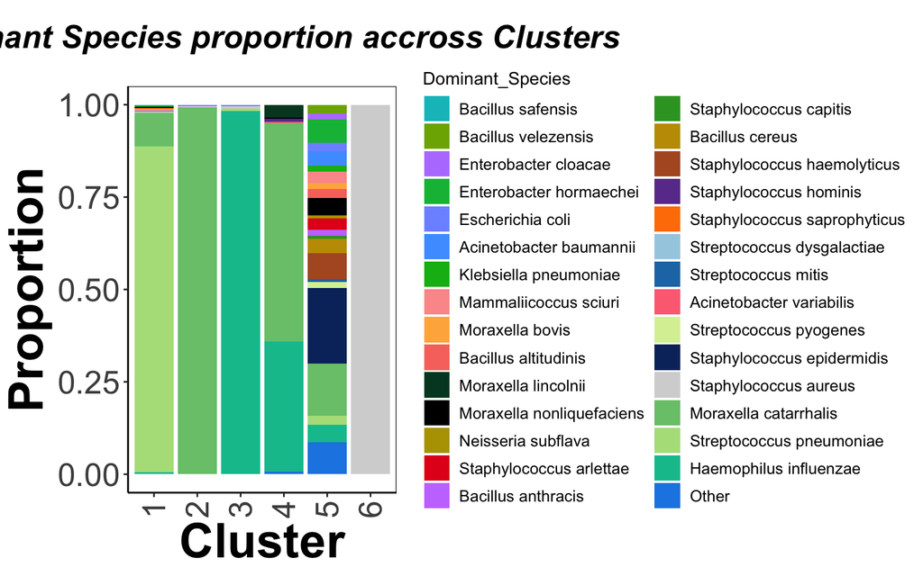

### Species co-colonising samples accross clusters.

Additionally, the proportion of each species within individual samples across clusters was calculated and visualized using a stacked bar plot.

#### Proportion of species in samples.

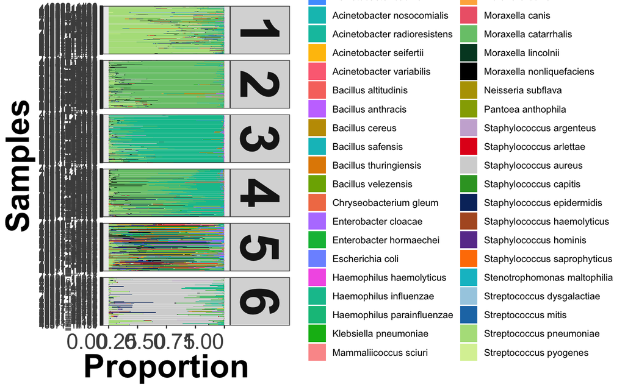

#### Proportion of top 10 species in samples.

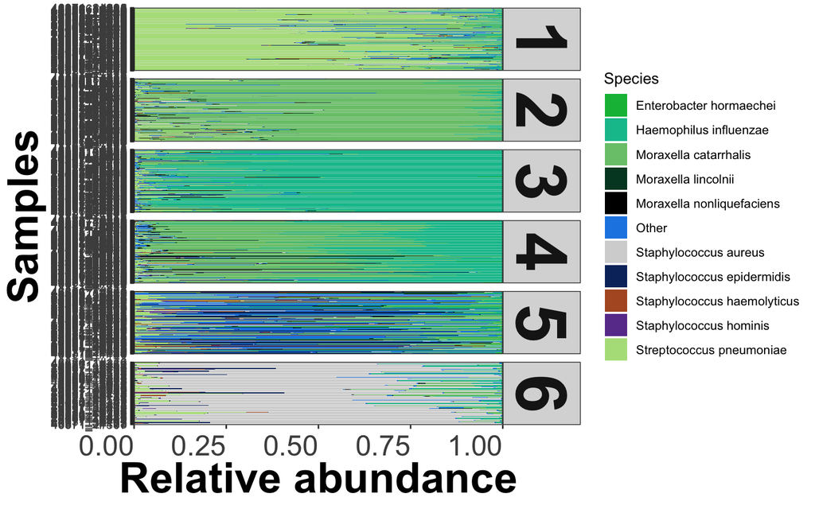

After sample clustering, I clustered species using bluster/TreeSummarizedExperiment/mia packages.

#### Add species cluster

To add species cluster:  
1. I first calculated the distance between species.  
2. I converted the distance matrix into hclust object and use cutree function to add specie clusters.  
3. I ordered clusters and ploted using r base.

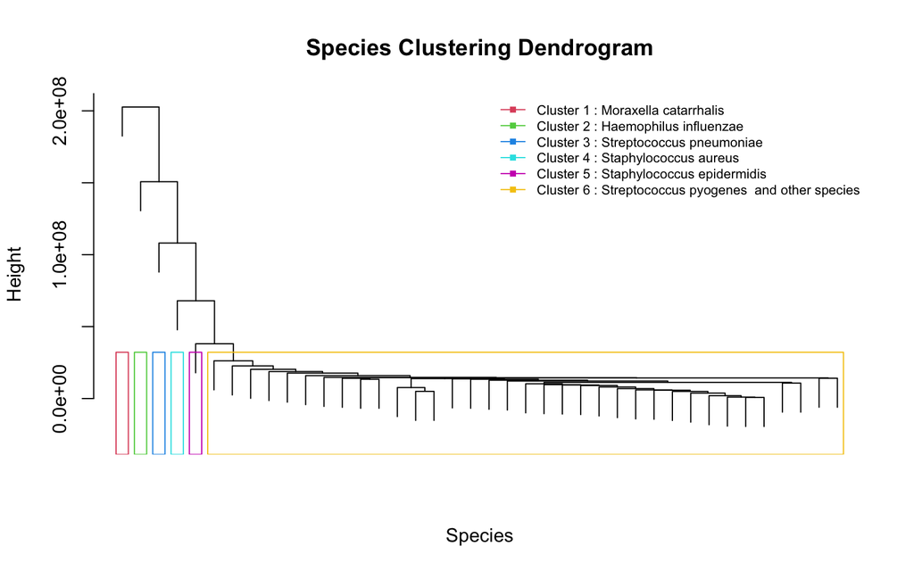

#### UMAP Analysis of Mixed Bacterial Samples to Reveal structure.

To further explore patterns in species composition, a UMAP analysis was performed on species abundance data using the UMAP package, and samples were colored according to previously defined clusters.

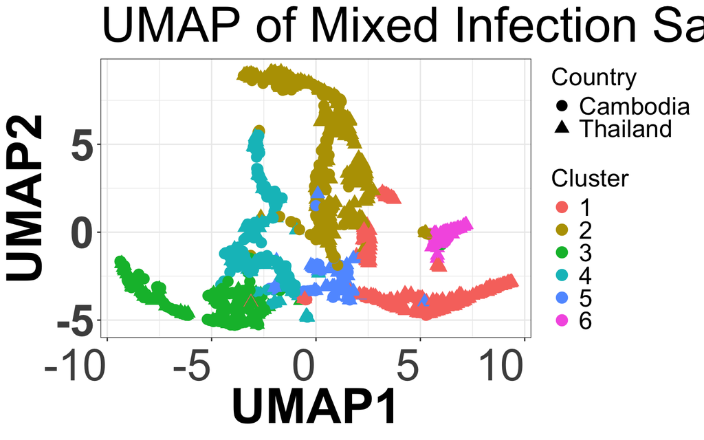

# Genome-wide association analysis

## Genome assembly using SPAdes

Metagenomic samples enriched for *Moraxella catarrhalis* were assembled using SPAdes prior to downstream comparative genomics and GWAS analysis.

```bash
spades.py \
  --careful \
  -1 sample_R1.fastq.gz \
  -2 sample_R2.fastq.gz \
  -o spades_output/
```

# Kraken2 filtering of *Moraxella catarrhalis* contigs

To minimise contamination from mixed metagenomic assemblies, contigs assigned to *Moraxella catarrhalis* were extracted using Kraken2 classification and SeqKit filtering.

```bash
#!/bin/bash

module load kraken2/2.1.2
module load seqkit/v2.9.0

SPADES_DIR="spades_mcat_only"
OUTDIR="spades_mcat_kraken_filtered"

THREADS=8
TAXID=480

for f in "$SPADES_DIR"/*.fasta
do

    sample=$(basename "$f" .fasta)

    kraken2 \
        --db k2_standard_08gb \
        --threads "$THREADS" \
        --report "$OUTDIR/${sample}.report" \
        --output "$OUTDIR/${sample}.kraken.out" \
        "$f"

    awk -v tax="$TAXID" \
      '$3==tax {print $2}' \
      "$OUTDIR/${sample}.kraken.out" \
      > "$OUTDIR/${sample}.mcat.ids"

    seqkit grep \
      -f "$OUTDIR/${sample}.mcat.ids" \
      "$f" \
      > "$OUTDIR/${sample}.Mcat.fasta"

done
```

Only contigs classified as *Moraxella catarrhalis* were retained for downstream unitig-based GWAS analysis.

# Unitig calling

Unitigs were generated from filtered *Moraxella catarrhalis* assemblies using `unitig-caller`.

```bash
#!/bin/bash

module load unitig-caller/1.3.0

unitig-caller \
    --call \
    --refs Mcat_clean_list.txt \
    --pyseer \
    --out unitig_mcat \
    --kmer 31 \
    --threads 8
```

Unitig presence–absence matrices were generated for Pyseer-compatible bacterial GWAS analysis.

# Mash distance matrix generation

Pairwise Mash distances were calculated to estimate genome similarity between *Moraxella catarrhalis* isolates.

```bash
#!/bin/bash

module load mash/2.1.1

find spades_mcat_kraken_filtered \
  -name "*.Mcat.fasta" \
  > assemblies.txt

mash sketch \
    -p 16 \
    -l assemblies.txt

mash dist \
    assemblies.txt.msh \
    assemblies.txt.msh \
    > mcat_mash_square.tsv
```

# Convert Mash distances into kinship matrix

Mash distances were converted into a kinship matrix to account for bacterial population structure during GWAS analysis.

# Pyseer GWAS analysis

A linear mixed-model GWAS was performed using Pyseer with the Mash kinship matrix and unitig presence–absence data.

```bash
#!/bin/bash

module load pyseer/1.4.0

pyseer \
  --phenotypes Mcat_phenotype_pyseer.txt \
  --kmers unitig_mcat_fixed.pyseer.gz \
  --similarity mcat_mash_kinship_matrix.tsv \
  --lmm \
  --min-af 0.01 \
  --cpu 8 \
  > mcat_pyseer_unitig_results_update.txt
```

Significant unitigs associated with *M. catarrhalis* co-colonisation phenotypes were identified using a linear mixed-model framework controlling for genomic relatedness.

# Extract significant unitigs

```bash
awk '$4 < 1e-10 {print $1}' \
mcat_pyseer_unitig_results_update.txt \
> significant_kmers.txt
```

Significant unitigs were subsequently annotated and visualised using downstream R analyses and Manhattan plots.

## Downstream analysis

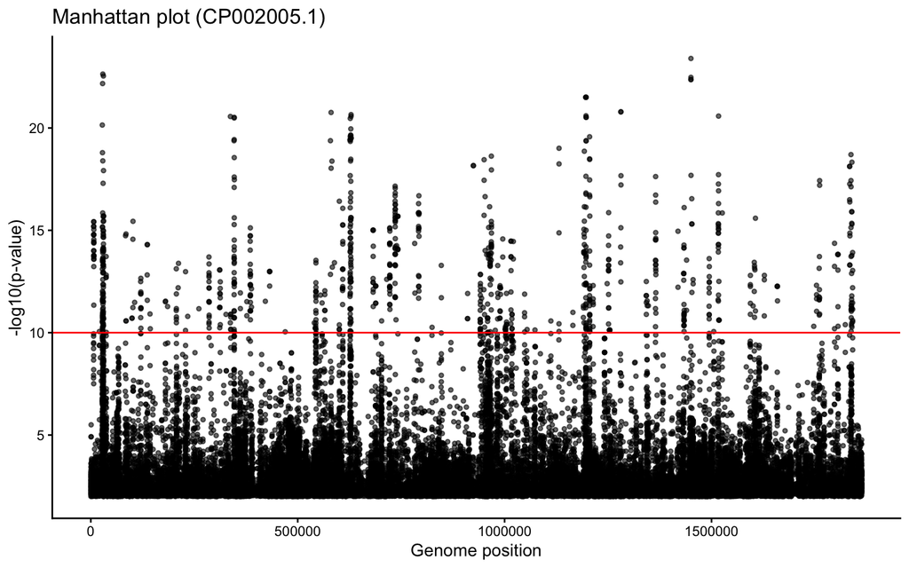

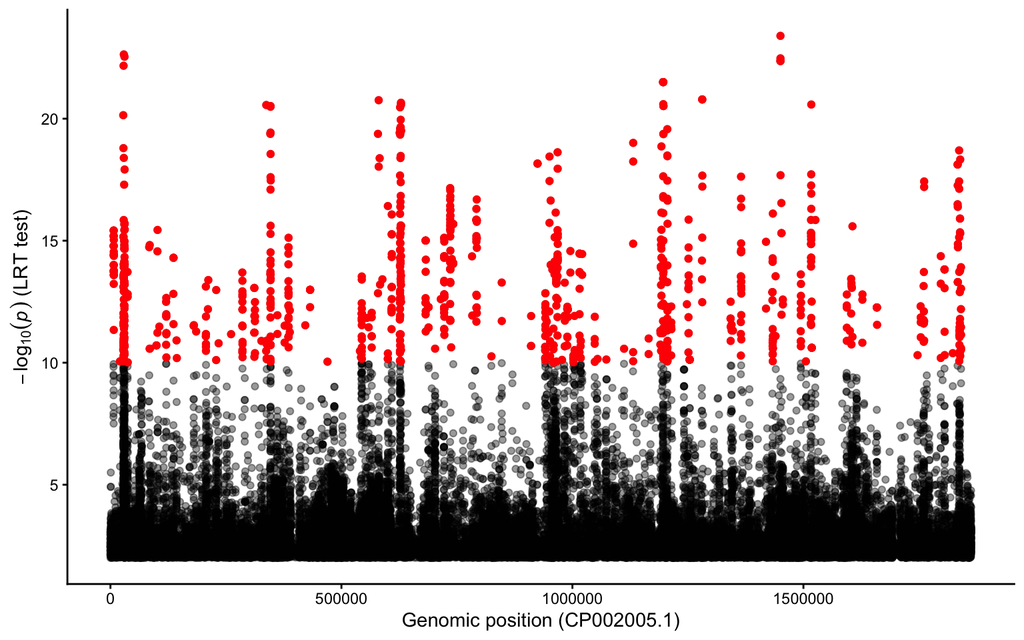

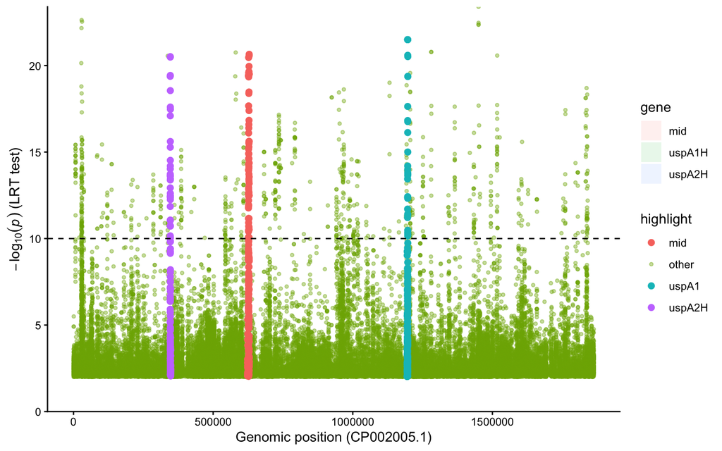

- Do seroresistant and serosensitive Moraxellae appear to compete?
- Are these patterns consistent across countries?
- Is there variation with age in Maela? (mother v. infant, changes in first year)
- Is there variation in acute/non-acute in Maela?

## Co-colonisation analysis of strains

- Is the same pattern of co-colonisation observed across species (including serosensitive/seroresistant Moraxellae)?
- Seroresistant/serosensitive difference in acute in Maela?
- Is the same level of co-colonisation observed across countries?
- Removal of prophage sequences - does this improve assignment to strains?
- Are long-read references better than short-read references?

## Timing of antibiotic administration and species presence

- Are different species enriched after antibiotic administration in Maela?
- Is there less co-colonisation between strains after antibiotic administration?